# What are the characteristics of a hit song?

By Casey Puentes

The dataset used in this analysis is available online at https://www.kaggle.com/datasets/sashankpillai/spotify-top-200-charts-20202021.

## Introduction

With the rise of new social media apps like TikTok, music is now practically unavoidable. A staggering number of 60,000 new songs (https://www.musicbusinessworldwide.com/over-60000-tracks-are-now-uploaded-to-spotify-daily-thats-nearly-one-per-second/) are uploaded to Spotify every day. While creators and the amount of music producdd is flourishing, not every song can be a hit with roughly 57,000 artists sharing 90% of the total streams on Spotify. Streaming services, like Spotify, give us helpful insights through data as to what characteristics some of the worlds most popular songs share.

For this project, I chose to use a dataset from Kaggle consisting of all songs on Spotifys top 200 chart from 2020 to 2021. This dataset includes many different types of information ranging from song name, to release date, and even to specific features of the song such as popularity and key. For my analysis, we will be using the following columns:

- **Song Name**: The songs name
- **Streams**: The total number of times a song has been streamed
- **Highest Charting Position**: The highest position on the top 200 charts this song has ever reached between 2020 and 2021.
- **Number of Times Charted**: The amount of weeks this song was placed on the top 200 charts between 2020 and 2021.
- **Artist**: The Artist(s) for a given song
- **Artist Followers**: The number of followers an artist has
- **Genre**: The genre(s) of a song

The following are specific characteristics about a songs acoustics and flow. These will be very interesting to explore in terms of data analysis:

- **Popularity**: Spotifys popularity rating of a song. Ranges from 0-100 with 100 being most popular.
- **Danceability**: This value represents how 'danceable' a song is based on its tempo, rhythm stability, beat strength, and overall regularity. This value can be anywhere between 0.0 and 1.0 with 0.0 being least and 1.0 being most danceable.
- **Acousticness**: A value between 0.0 and 1.0 that rates a songs acousticness.
- **Energy**: The overall energy of a song typically measured by the tempo, loudness, and tempo of a song. This value is restricted between 0.0 and 1.0 with 1.0 being the most energetic.
- **Instrumentalness**: The rating of a songs instrumentalness, or lack of vocals. Constrained between 0.0 and 1.0 where 1.0 is completely vocalless.
- **Liveness**: An estimation of whether or not the given song was recorded with a live audience. Constrained between 0.0 and 1.0 where 1.0 is most likely to have a live audience.
- **Loudness**: The average loudness of a song in decibles.
- **Speechiness**: The more this song is filled with speech only (such as talk shows), the higher this value will be(0.0 to 1.0).
- **Tempo**: The tempo or speed of the beat of a given song in BPM.
- **Valence**: The positiveness conveyed by a song rated from 0.0 to 1.0 with 1.0 being the most positive.
- **Chord**: The main chord of a songs instrumentals

Let's get started! :)

## Data Organization/Tidying

Lets begin by extracting the data from the csv and putting it into a dataframe.

```python
import pandas as pd

# Convert the csv into a dataframe
df = pd.read_csv("./spotify_dataset.csv", sep=',')
df = pd.DataFrame(df)
df.head()
```

|  | Index | Highest Charting Position | Number of Times Charted | Week of Highest Charting | Song Name | Streams | Artist | Artist Followers | Song ID | Genre | ... | Danceability | Energy | Loudness | Speechiness | Acousticness | Liveness | Tempo | Duration (ms) | Valence | Chord |
| --- | --- | --- | --- | --- | --- | --- | --- | --- | --- | --- | --- | --- | --- | --- | --- | --- | --- | --- | --- | --- | --- |
| 0 | 1 | 1 | 8 | 2021-07-23--2021-07-30 | Beggin' | 48,633,449 | Måneskin | 3377762 | 3Wrjm47oTz2sjIgck11l5e | ['indie rock italiano', 'italian pop'] | ... | 0.714 | 0.8 | -4.808 | 0.0504 | 0.127 | 0.359 | 134.002 | 211560 | 0.589 | B |
| 1 | 2 | 2 | 3 | 2021-07-23--2021-07-30 | STAY (with Justin Bieber) | 47,248,719 | The Kid LAROI | 2230022 | 5HCyWlXZPP0y6Gqq8TgA20 | ['australian hip hop'] | ... | 0.591 | 0.764 | -5.484 | 0.0483 | 0.0383 | 0.103 | 169.928 | 141806 | 0.478 | C#/Db |
| 2 | 3 | 1 | 11 | 2021-06-25--2021-07-02 | good 4 u | 40,162,559 | Olivia Rodrigo | 6266514 | 4ZtFanR9U6ndgddUvNcjcG | ['pop'] | ... | 0.563 | 0.664 | -5.044 | 0.154 | 0.335 | 0.0849 | 166.928 | 178147 | 0.688 | A |
| 3 | 4 | 3 | 5 | 2021-07-02--2021-07-09 | Bad Habits | 37,799,456 | Ed Sheeran | 83293380 | 6PQ88X9TkUIAUIZJHW2upE | ['pop', 'uk pop'] | ... | 0.808 | 0.897 | -3.712 | 0.0348 | 0.0469 | 0.364 | 126.026 | 231041 | 0.591 | B |
| 4 | 5 | 5 | 1 | 2021-07-23--2021-07-30 | INDUSTRY BABY (feat. Jack Harlow) | 33,948,454 | Lil Nas X | 5473565 | 27NovPIUIRrOZoCHxABJwK | ['lgbtq+ hip hop', 'pop rap'] | ... | 0.736 | 0.704 | -7.409 | 0.0615 | 0.0203 | 0.0501 | 149.995 | 212000 | 0.894 | D#/Eb |

5 rows × 23 columns

Now we have our dataset loaded into in a dataframe! Our next step is to tidy the data in whatever ways we can. Essentially, this just means that we need to make our data as complete and easy to use as possible so that during our analysis, we don't run into any issues or allow our data to be skewed. Typically, this consists of three main things: 1. Removing columns you aren't going to use, 2. Handling missing values, and 3. Converting data in the columns to the easiest-to-use/optimal forms(e.g. converting date strings to datetime objects). Let's start by removing the columns we don't need.

### Removing Obselete Columns

```python
# First, lets print out all of the current columns that the dataframe has so we can compare after dropping the columns to verify
# its success.
print("Before: \n" + str(df.columns.values))

# Drop unnecessary columns - I listed the columns that I need to use above so lets remove anything not mentioned!
df = df.drop(columns=["Song ID", "Weeks Charted", "Week of Highest Charting"])

# Print columns again to double check we did this correctly
print("After: \n" + str(df.columns.values))
```

```
Before:
['Index' 'Highest Charting Position' 'Number of Times Charted'
 'Week of Highest Charting' 'Song Name' 'Streams' 'Artist'
 'Artist Followers' 'Song ID' 'Genre' 'Release Date' 'Weeks Charted'
 'Popularity' 'Danceability' 'Energy' 'Loudness' 'Speechiness'
 'Acousticness' 'Liveness' 'Tempo' 'Duration (ms)' 'Valence' 'Chord']
After:
['Index' 'Highest Charting Position' 'Number of Times Charted' 'Song Name'
 'Streams' 'Artist' 'Artist Followers' 'Genre' 'Release Date' 'Popularity'
 'Danceability' 'Energy' 'Loudness' 'Speechiness' 'Acousticness'
 'Liveness' 'Tempo' 'Duration (ms)' 'Valence' 'Chord']
```

Great! Now we can work on tidying up the rows that we're planning on using. Lets move onto the second step: handling missing values.

### Handling Missing Values

There are a couple of different types of scenarios in which our data could be considered to have 'missing values.' For example, the data could have null values or empty strings. Lets start by checking to see whether or not our data contains any Null values.

```python
# Check rows to see if they have any null values
df.isna()
```

|  | Index | Highest Charting Position | Number of Times Charted | Song Name | Streams | Artist | Artist Followers | Genre | Release Date | Popularity | Danceability | Energy | Loudness | Speechiness | Acousticness | Liveness | Tempo | Duration (ms) | Valence | Chord |
| --- | --- | --- | --- | --- | --- | --- | --- | --- | --- | --- | --- | --- | --- | --- | --- | --- | --- | --- | --- | --- |
| 0 | False | False | False | False | False | False | False | False | False | False | False | False | False | False | False | False | False | False | False | False |
| 1 | False | False | False | False | False | False | False | False | False | False | False | False | False | False | False | False | False | False | False | False |
| 2 | False | False | False | False | False | False | False | False | False | False | False | False | False | False | False | False | False | False | False | False |
| 3 | False | False | False | False | False | False | False | False | False | False | False | False | False | False | False | False | False | False | False | False |
| 4 | False | False | False | False | False | False | False | False | False | False | False | False | False | False | False | False | False | False | False | False |
| ... | ... | ... | ... | ... | ... | ... | ... | ... | ... | ... | ... | ... | ... | ... | ... | ... | ... | ... | ... | ... |
| 1551 | False | False | False | False | False | False | False | False | False | False | False | False | False | False | False | False | False | False | False | False |
| 1552 | False | False | False | False | False | False | False | False | False | False | False | False | False | False | False | False | False | False | False | False |
| 1553 | False | False | False | False | False | False | False | False | False | False | False | False | False | False | False | False | False | False | False | False |
| 1554 | False | False | False | False | False | False | False | False | False | False | False | False | False | False | False | False | False | False | False | False |
| 1555 | False | False | False | False | False | False | False | False | False | False | False | False | False | False | False | False | False | False | False | False |

1556 rows × 20 columns

From a glance, it looks like our data does not contain any null values. However, it's impractical to look through 1556 rows to make sure that all of the results return false. Let's try a different function to determine if there are any null values.

```python
# Check if there are any null values in the entire dataframe
df.isnull().values.any()
```

```
False
```

As shown above, we have no null values that we need to worry about within our data set. Lets now check to see if there are any empty strings.

```python
# Iterating over every column, check each one individually to see if they contain any empty strings
for curCol in df.columns.values:
    if "" in set(df[curCol]) or " " in set(df[curCol]):
        print("Missing values detected!")
```

```
Missing values detected!
Missing values detected!
Missing values detected!
Missing values detected!
Missing values detected!
Missing values detected!
Missing values detected!
Missing values detected!
Missing values detected!
Missing values detected!
Missing values detected!
Missing values detected!
Missing values detected!
Missing values detected!
```

```python
for idx, curRow in df.iterrows():
    curPop = curRow["Tempo"]
    if curPop == "" or curPop == " ":
        print("Data missing from song: " + curRow["Song Name"])
```

```
Data missing from song: NOT SOBER (feat. Polo G & Stunna Gambino)
Data missing from song: 34+35
Data missing from song: Richer (feat. Polo G)
Data missing from song: 34+35 Remix (feat. Doja Cat, Megan Thee Stallion) - Remix
Data missing from song: Driving Home for Christmas - 2019 Remaster
Data missing from song: Thank God It's Christmas - Non-Album Single
Data missing from song: Agua (with J Balvin) - Music From "Sponge On The Run" Movie
Data missing from song: Lean (feat. Towy, Osquel, Beltito & Sammy & Falsetto)
Data missing from song: +Linda
Data missing from song: In meinem Benz
Data missing from song: fuck, i'm lonely (with Anne-Marie) - from “13 Reasons Why: Season 3”
```

We're going to need this data for our analysis, however, as we can see, we simply don't have the data. We could find the data online ourselves(likely through using Spotifys API) and add it to the dataset manually. This method is known as imputation which is essentially replacing missing data with substitue data which, in this case, would be the data from Spotify(or we could even compute an average through mean imputation). But by seeing how this missing data affects only 11 songs, let us first consider how big of an impact this missing data may have before moving forward with imputation.

```python
# Get the total number of songs in the dataset and divide it by the number of songs that have missing data(11) to see what percentage
# of the data our missing 11 represent
print(str(11/(len(df))))
```

```
0.007069408740359897
```

We can see here that the incomplete songs represent a measly 0.7% of our overall data. Therefore, it's safe to conclude that we can simply remove these songs from our data as it will have a minimal affect on our overall result.

```python
# Drop the rows with missing data
df = df[df.Tempo != " "]
```

Now that we've handled all of the missing data, lets move onto the last part of tidying: Coverting data to its optimal form

### Converting data to its optimal form

Having data in the most easy-to-use form makes it much easier to perform exploratory data analysis. Let's figure out what data could be stored in a more efficient manner by using the pandas df.dtypes (https://pandas.pydata.org/docs/reference/api/pandas.DataFrame.dtypes.html) method.

```python
# Check each columns data types:
print(df.dtypes)
```

```
Index                         int64
Highest Charting Position     int64
Number of Times Charted       int64
Song Name                    object
Streams                      object
Artist                       object
Artist Followers             object
Genre                        object
Release Date                 object
Popularity                   object
Danceability                 object
Energy                       object
Loudness                     object
Speechiness                  object
Acousticness                 object
Liveness                     object
Tempo                        object
Duration (ms)                object
Valence                      object
Chord                        object
dtype: object
```

Notice how most of the columns are of the 'object' type, which is essentially a string in pandas(https://pbpython.com/pandas_dtypes.html). For some columns like Artist and Song Name, this makes sense, but for others like Streams and Artist Followers, it makes more sense to have these be numeric. However, before we're able to do this, we need to fix a couple things. The "Streams" column contains ,'s inbetween numbers. They need to be removed in order to allow the numeric conversion to run correctly. Lets fix that right now.

```python
# Remove the ,'s from the streams objects
df["Streams"] = df["Streams"].str.replace(",", "")
```

Now that we've converted the streams to parseable numbers, let's get to the parsing!

```python
# Convert the listed columns to numbers (parsing)
df[["Streams", "Artist Followers", "Popularity","Danceability", "Energy", "Loudness", "Speechiness", "Acousticness",
    "Liveness", "Tempo", "Duration (ms)", "Valence"]] = df[["Streams", "Artist Followers", "Popularity","Danceability",
                                                            "Energy", "Loudness", "Speechiness", "Acousticness",
                                                            "Liveness", "Tempo", "Duration (ms)", "Valence"]].apply(pd.to_numeric)

# Double check that the types are updated correctly
print(df.dtypes)
```

```
Index                          int64
Highest Charting Position      int64
Number of Times Charted        int64
Song Name                     object
Streams                        int64
Artist                        object
Artist Followers               int64
Genre                         object
Release Date                  object
Popularity                     int64
Danceability                 float64
Energy                       float64
Loudness                     float64
Speechiness                  float64
Acousticness                 float64
Liveness                     float64
Tempo                        float64
Duration (ms)                  int64
Valence                      float64
Chord                         object
dtype: object
```

One more minor thing that could make things easier in terms of visualization is converting the duration to seconds instead of milliseconds. Lets make the conversion and rename the column accordingly.

```python
# Convert the duration from ms to seconds
df["Duration (ms)"] = df["Duration (ms)"].apply(lambda x: x/1000)

# Rename the duration column to represent seconds instead of milliseconds (ms)
df = df.rename(columns={"Duration (ms)": "Duration (s)"})

# Double check that our changes have stuck
df.head()
```

|  | Index | Highest Charting Position | Number of Times Charted | Song Name | Streams | Artist | Artist Followers | Genre | Release Date | Popularity | Danceability | Energy | Loudness | Speechiness | Acousticness | Liveness | Tempo | Duration (s) | Valence | Chord |
| --- | --- | --- | --- | --- | --- | --- | --- | --- | --- | --- | --- | --- | --- | --- | --- | --- | --- | --- | --- | --- |
| 0 | 1 | 1 | 8 | Beggin' | 48633449 | Måneskin | 3377762 | ['indie rock italiano', 'italian pop'] | 2017-12-08 | 100 | 0.714 | 0.800 | -4.808 | 0.0504 | 0.1270 | 0.3590 | 134.002 | 211.560 | 0.589 | B |
| 1 | 2 | 2 | 3 | STAY (with Justin Bieber) | 47248719 | The Kid LAROI | 2230022 | ['australian hip hop'] | 2021-07-09 | 99 | 0.591 | 0.764 | -5.484 | 0.0483 | 0.0383 | 0.1030 | 169.928 | 141.806 | 0.478 | C#/Db |
| 2 | 3 | 1 | 11 | good 4 u | 40162559 | Olivia Rodrigo | 6266514 | ['pop'] | 2021-05-21 | 99 | 0.563 | 0.664 | -5.044 | 0.1540 | 0.3350 | 0.0849 | 166.928 | 178.147 | 0.688 | A |
| 3 | 4 | 3 | 5 | Bad Habits | 37799456 | Ed Sheeran | 83293380 | ['pop', 'uk pop'] | 2021-06-25 | 98 | 0.808 | 0.897 | -3.712 | 0.0348 | 0.0469 | 0.3640 | 126.026 | 231.041 | 0.591 | B |
| 4 | 5 | 5 | 1 | INDUSTRY BABY (feat. Jack Harlow) | 33948454 | Lil Nas X | 5473565 | ['lgbtq+ hip hop', 'pop rap'] | 2021-07-23 | 96 | 0.736 | 0.704 | -7.409 | 0.0615 | 0.0203 | 0.0501 | 149.995 | 212.000 | 0.894 | D#/Eb |

With those columns adjusted accordingly, we now can shift our focus to the remaining columns: Song Name, Artist, Genre, Release Date, and Chord. It makes sense to keep the Song Name, Artist, and Chord as objects. However, the Release Date should be converted to a datetime object to help make our analysis easier down the line. Additionally, the genre column could also be converted to a list. Lets start by converting the Release Dates into datetime objects.

By looking at the Release Date column, we see that they're generally in the form of YYYY-MM-DD. We can take advantage of this pattern by using some substringing and datetime creation.

```python
import datetime

# Loop through every release date and create a datetime object
df["Release Date"] = df['Release Date'].apply(lambda x: datetime.datetime(int(x.split("-")[0]), int(x.split("-")[1]),
                                                                          int(x.split("-")[2])) if len(str(x)) > 9 else None)

# Verify that our changes have been made
df.head()
df.dtypes
```

```
Index                                 int64
Highest Charting Position             int64
Number of Times Charted               int64
Song Name                            object
Streams                               int64
Artist                               object
Artist Followers                      int64
Genre                                object
Release Date                 datetime64[ns]
Popularity                            int64
Danceability                        float64
Energy                              float64
Loudness                            float64
Speechiness                         float64
Acousticness                        float64
Liveness                            float64
Tempo                               float64
Duration (s)                        float64
Valence                             float64
Chord                                object
dtype: object
```

Now that our dates our stored accordingly, lets convert the genres object to something we can work with. Originally, I was thinking of converting the genres to a series or list and storing that in the column but after further consideration, that may not be the most efficient way to store this data, especially if we want to create a plot or graph based on genre popularity in the exploratory data analysis. Instead, we will use a very interesting method called "exploding."(https://pandas.pydata.org/docs/reference/api/pandas.DataFrame.explode.html) This essentially turns each list element per song into its own row, making it easier to analyze. However, this can greatly increase the number of entries in dataframe, so we will store this exploded dataframe separately from the original.

```python
# Create a deep copy of the data frame
dfExploded = df.copy(deep=True)

# Making the genres object easier to parse when exploding by removing the brackets and commas.
dfExploded["Genre"] = dfExploded["Genre"].apply(lambda x: x.replace('[', ""))
dfExploded["Genre"] = dfExploded["Genre"].apply(lambda x: x.replace(']', ""))
dfExploded["Genre"] = dfExploded["Genre"].apply(lambda x: x.replace("'", ""))
```

At this point, we have a copy of the dataframe with the genres column ready to be converted into an actual list and prepped for explosion. Lets now move forward with that list conversion and explode the dataframe based on the list genres.

```python
# Create a list to store all of the genres in a row
genres = list()

# Get all of genres for a song, convert them to a list, and add them to the genres list for explosion.
for idx, curRow in dfExploded.iterrows():
    unparsedGenres = curRow["Genre"]

    # Split the genres by commas
    splitGenres = unparsedGenres.split(", ")

    if len(splitGenres) > 1:
        genres.append(splitGenres)
    else:
        genres.append(["no genre listed"])

dfExploded["List of Genres"] = genres

# Explode the genres dataframe
dfExploded = dfExploded.explode("List of Genres")

# Drop the old genres column as we don't need it anymore
dfExploded = dfExploded.drop(columns=["Genre"])

dfExploded.head()
```

|  | Index | Highest Charting Position | Number of Times Charted | Song Name | Streams | Artist | Artist Followers | Release Date | Popularity | Danceability | Energy | Loudness | Speechiness | Acousticness | Liveness | Tempo | Duration (s) | Valence | Chord | List of Genres |
| --- | --- | --- | --- | --- | --- | --- | --- | --- | --- | --- | --- | --- | --- | --- | --- | --- | --- | --- | --- | --- |
| 0 | 1 | 1 | 8 | Beggin' | 48633449 | Måneskin | 3377762 | 2017-12-08 | 100 | 0.714 | 0.800 | -4.808 | 0.0504 | 0.1270 | 0.3590 | 134.002 | 211.560 | 0.589 | B | indie rock italiano |
| 0 | 1 | 1 | 8 | Beggin' | 48633449 | Måneskin | 3377762 | 2017-12-08 | 100 | 0.714 | 0.800 | -4.808 | 0.0504 | 0.1270 | 0.3590 | 134.002 | 211.560 | 0.589 | B | italian pop |
| 1 | 2 | 2 | 3 | STAY (with Justin Bieber) | 47248719 | The Kid LAROI | 2230022 | 2021-07-09 | 99 | 0.591 | 0.764 | -5.484 | 0.0483 | 0.0383 | 0.1030 | 169.928 | 141.806 | 0.478 | C#/Db | no genre listed |
| 2 | 3 | 1 | 11 | good 4 u | 40162559 | Olivia Rodrigo | 6266514 | 2021-05-21 | 99 | 0.563 | 0.664 | -5.044 | 0.1540 | 0.3350 | 0.0849 | 166.928 | 178.147 | 0.688 | A | no genre listed |
| 3 | 4 | 3 | 5 | Bad Habits | 37799456 | Ed Sheeran | 83293380 | 2021-06-25 | 98 | 0.808 | 0.897 | -3.712 | 0.0348 | 0.0469 | 0.3640 | 126.026 | 231.041 | 0.591 | B | pop |

With our data successfully tidied up, we can now finally move on to the fun part: the exploratory analysis!

## Exploratory Data Analysis

Our data is tidy and ready to be analyzed further. There are many different avenues that we could move now in terms of analysis, but lets start simply by simply testing to see whether or not any of the features of a song have a linear relationship with Popularity. A great way to do this is scatter plots with Popularity and the other numeric features.

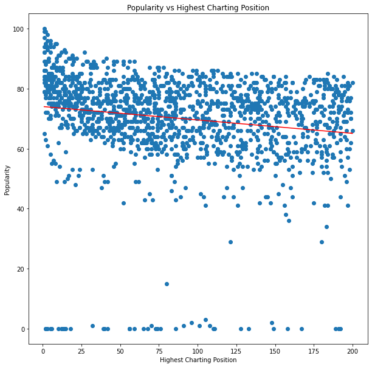

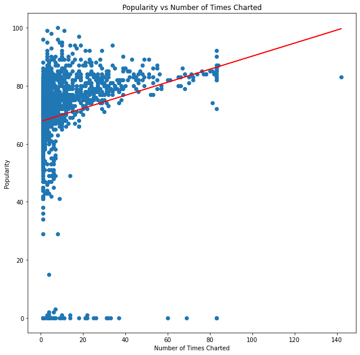

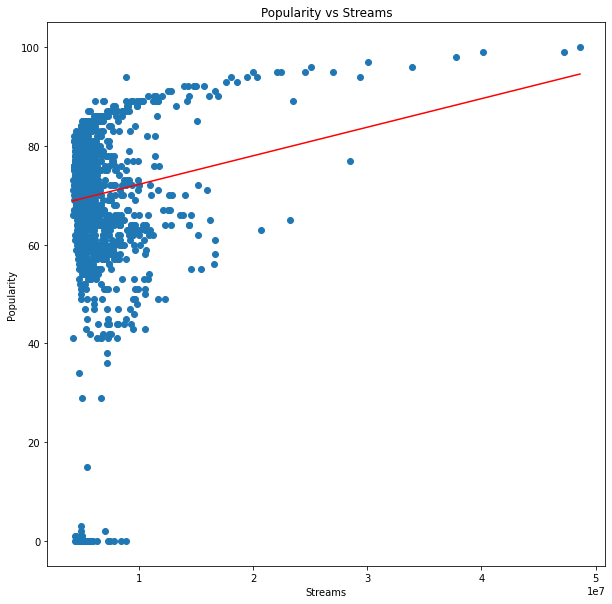

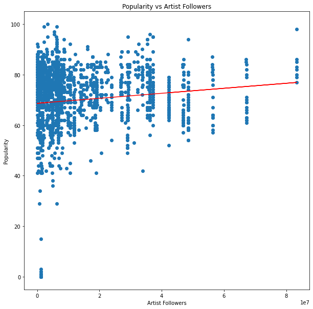

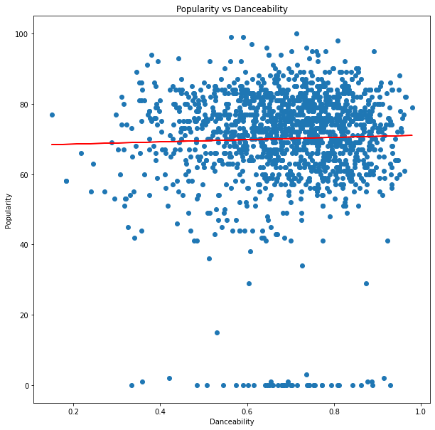

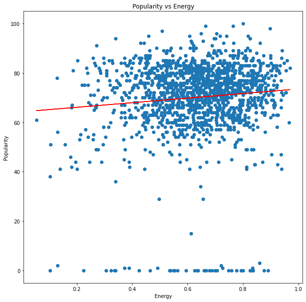

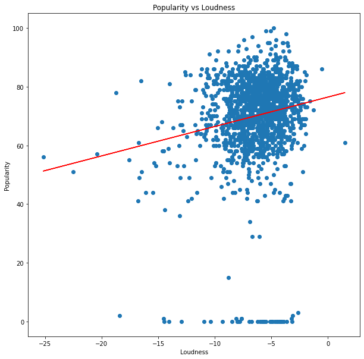

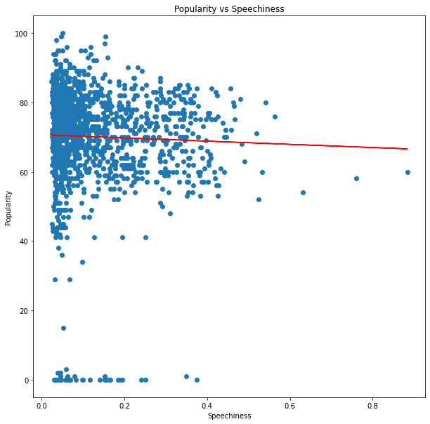

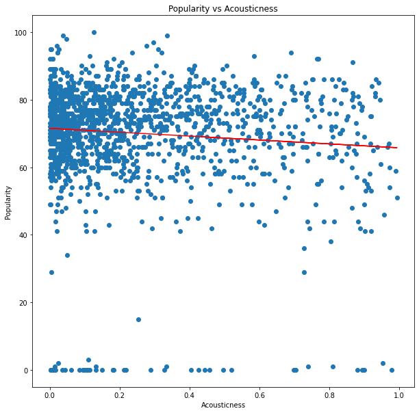

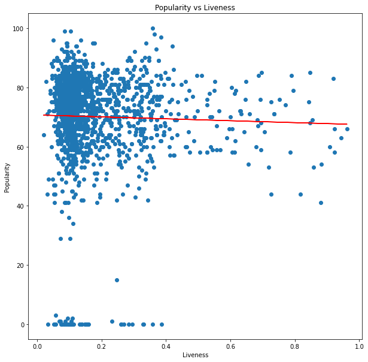

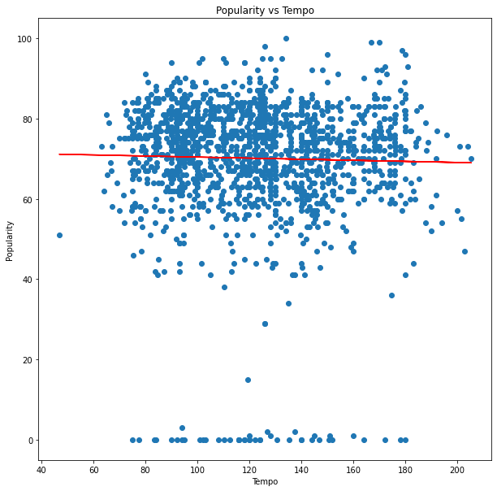

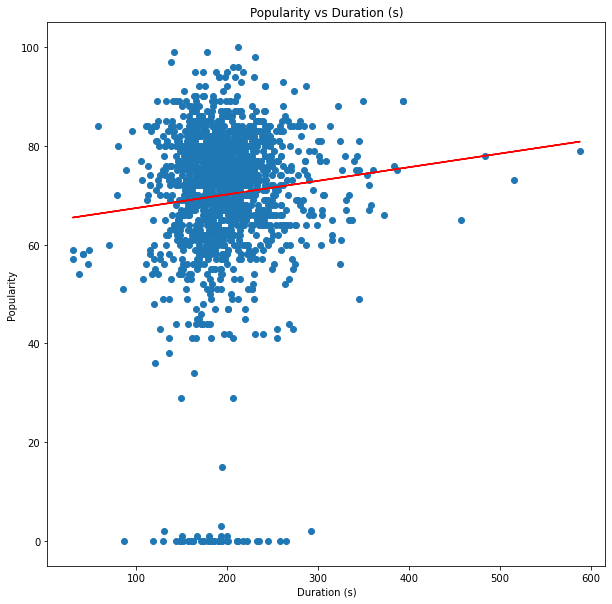

[1 more figures not shown]

```python
import numpy as np
import matplotlib.pyplot as plot

# Heres a list a of all of the different characteristics we are going to compare to popularity
columnsToPlot = ["Highest Charting Position", "Number of Times Charted", "Streams", "Artist Followers", "Danceability",
                 "Energy", "Loudness", "Speechiness", "Acousticness", "Liveness", "Tempo", "Duration (s)", "Valence"]

popularity = df["Popularity"]

# Create a graph with popularity and each other column
for curCol in columnsToPlot:
    # Set up the plot
    fig, ax = plot.subplots(figsize = (10,10))
    plot.ylabel("Popularity")
    plot.xlabel(curCol)
    plot.title("Popularity vs " + curCol)

    # Plot the values and show the plot
    plot.scatter(x=df[curCol], y=popularity)

    # Plot a linear regression line
    slope, intercept = np.polyfit(df[curCol], popularity, 1)
    plot.plot(df[curCol], slope * np.array(df[curCol]) + intercept, color="red")
    plot.show()
```

The relationship that these characteristics share with the popularity of a song is not immediately visible. However, here are some of the things we can derive from these scatter plots:

1. Many of the scatter plots have linear regression lines with seemingly no slope. This essentially translates to the fact that there is no correlation or relationship between these two characteristics.
2. Some of the graphs do show a slight pattern, though, such as the danceability scatter plot in which songs that are more danceable than not are more likely to end up on the top 200 charts.

Each of these plots are densely packed with information. In order to make this analysis easier and condense the information, lets calculate the average of the data by grouping it by popularity. To achieve this, I will be using the [groupby](https://pandas.pydata.org/docs/reference/api/pandas.DataFrame.groupby.html) function.

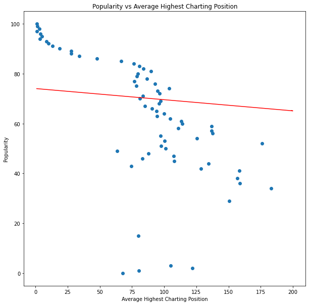

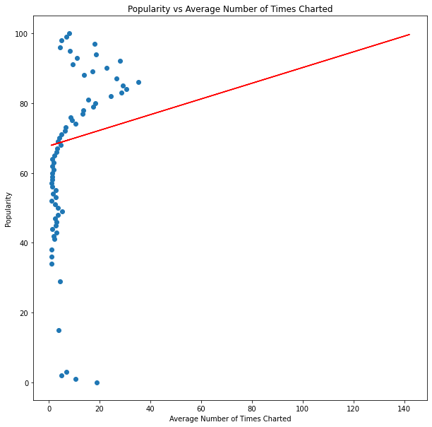

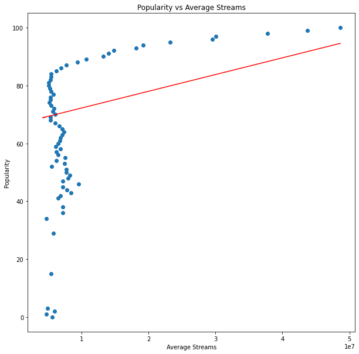

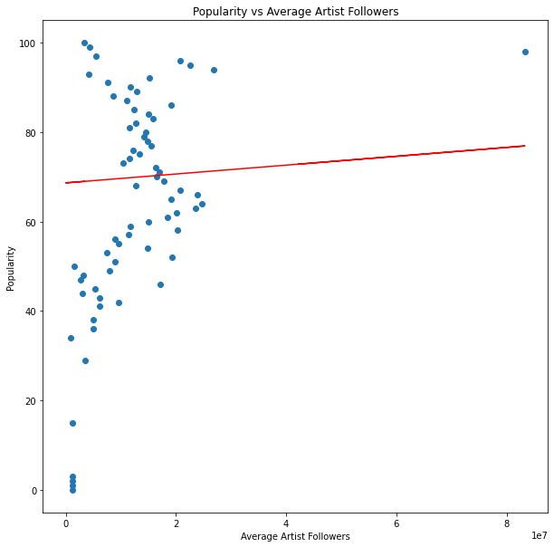

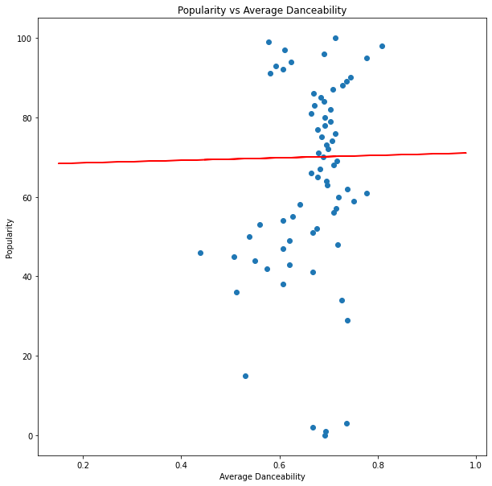

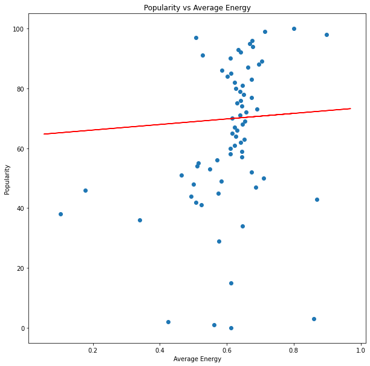

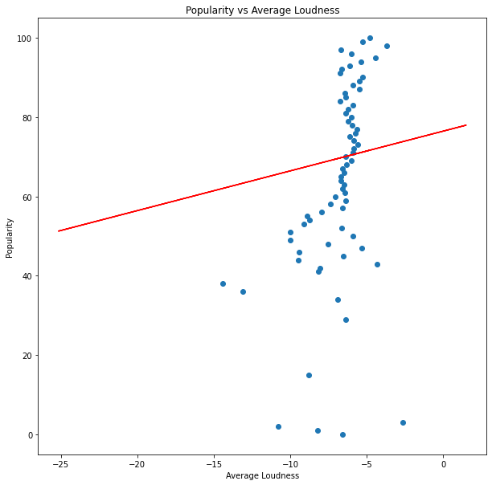

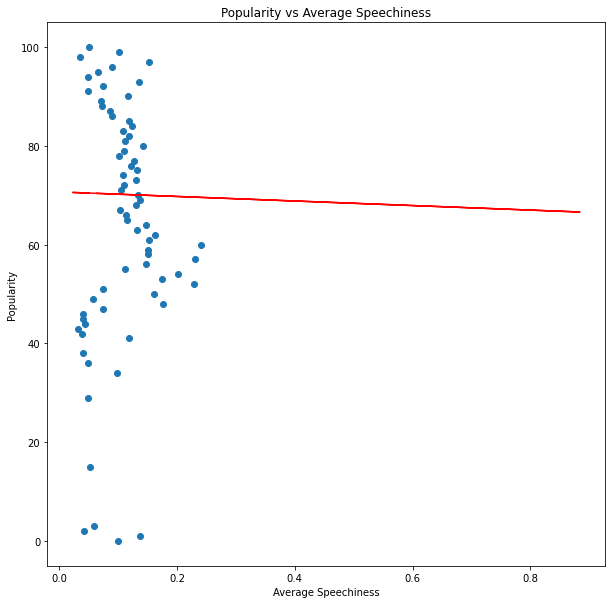

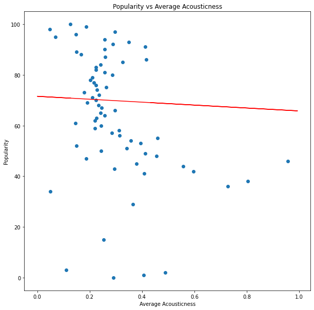

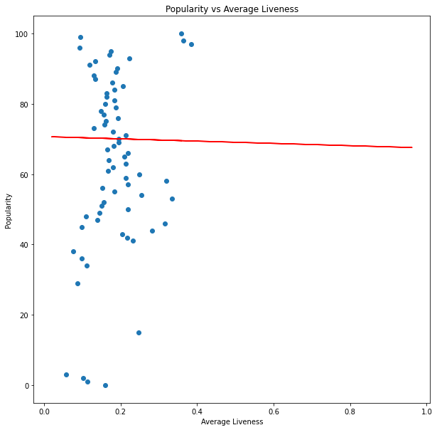

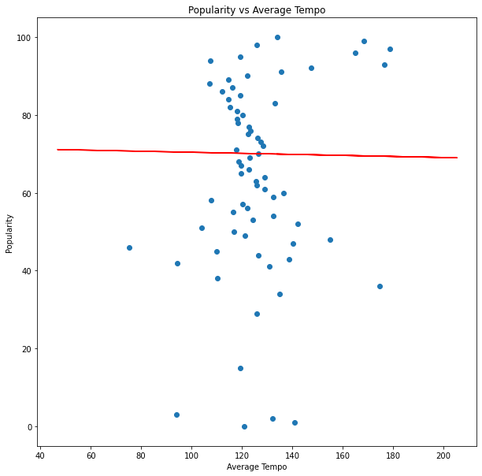

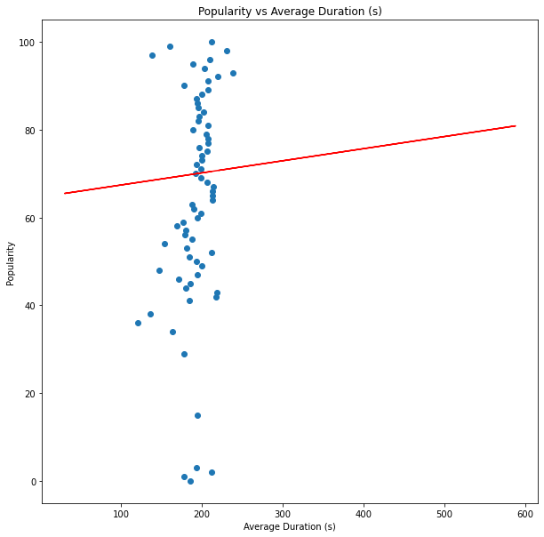

[1 more figures not shown]

```python
# Create a graph with popularity and each other column
for curCol in columnsToPlot:
    # Set up the plot
    fig, ax = plot.subplots(figsize = (10,10))
    plot.ylabel("Popularity")
    plot.xlabel("Average " + curCol)
    plot.title("Popularity vs Average " + curCol)

    # Create a temporary dataframe to house the mean data
    dfTemp = df.loc[:, ["Popularity", curCol]]

    # Convert the popularity to integers and cur column information to floats for computation purposes.
    dfTemp["Popularity"] = dfTemp["Popularity"].astype(int)
    dfTemp[curCol] = dfTemp[curCol].astype(float)

    # Calculate the average value across all of the popularity values
    dfMean = dfTemp.groupby("Popularity").mean()

    # Plot the values and show the plot
    plot.scatter(x=dfMean[curCol], y=dfMean.index)

    # Plot a linear regression line
    slope, intercept = np.polyfit(df[curCol], popularity, 1)
    plot.plot(df[curCol], slope * np.array(df[curCol]) + intercept, color="red")
    plot.show()
```

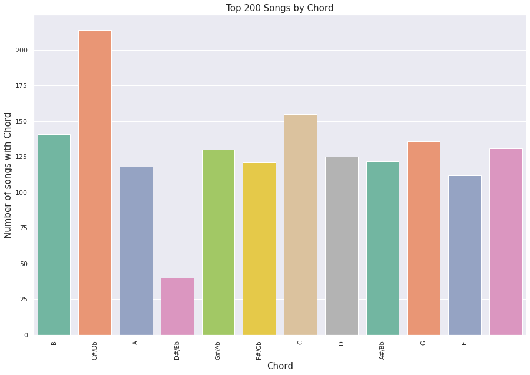

```python
import seaborn as sb

chordsFreq = dict()
numOfChords = 0

# Get the frequency of certain chords
for idx, row in df.iterrows():
    chord = row["Chord"]
    numOfChords += 1
    if chord in chordsFreq:
        chordsFreq[chord] = chordsFreq[chord] + 1
    else:
        chordsFreq[chord] = 1

xAxis = list()
yAxis = list()

# Consolidate the chordsFreq into the x and y axis lists.
for (key, val) in chordsFreq.items():
    xAxis.append(key)
    yAxis.append(val)
sb.set(rc = {'figure.figsize':(15,10)})
ax1 = sb.barplot(x=xAxis, y=yAxis, palette="Set2")
ax1.set_xticklabels(ax1.get_xticklabels(), fontsize=10, rotation=90)

# Add labels to the plot for easy reading
plot.xlabel("Chord", size=15)
plot.ylabel("Number of songs with Chord", size=15)
plot.title("Top 200 Songs by Chord", size=15)
```

Great! Now we have an easy-to-read bar graph consisting of the most popular main chords for hit songs. At a quick glance, we can see that the chords are all over the place in terms of frequency with D#/Eb being the least popular and C#/Db being the most popular. What this means is that songs that make the top 200 charts on Sptofiy mainly consist of the main chord of C#/Db while the least popular chord for charting songs is D#/Eb. Safe to say that if you want a hit song, make it in C#/Db!

With this information, we now understand a lot about what sort characteristics are more frequently associated with a hit song. Let's now try and see if we'll be able to leverage this information and make predictions about the next hit songs.

## Machine Learning

Decision trees are a powerful tool for both classification and regression tasks in machine learning. They are easy to interpret and can be visualized, which makes them a popular choice. However, decision trees can be prone to overfitting, especially when working with high-dimensional data. In addition, decision trees do not perform well when the data is not linearly separable. When working with decision trees, it is important to be aware of these limitations. Let's move forward with our decision tree

I've decided to train the decision tree to determine whether a song is considered very popular (Popularity value >= 80) by using 5 different numeric features of the data:

1. Energy
2. Tempo
3. Acousticness
4. Liveness
5. Duration (s)

We will first have to split our dataframe into two parts, one for training of the decision tree and another for evaluating its accuracy. Then, we'll have to use the training date to train the decision tree. Finally, we'll evaluate the accuracy overall.

```python
from sklearn.tree import DecisionTreeClassifier
import matplotlib.image as pltimg
from sklearn import tree

# Create new dataframe
dfCopy = df.copy(deep=True)

# Create a new column based on whether or not the popularity of a song is over 80 (considered a very popular song)
popularityScore = []
for index,row in dfCopy.iterrows():
    if row['Popularity'] >= 80:
        popularityScore.append(1)
    else:
        popularityScore.append(0)

# Split the dataframe into two parts: One to train the decision tree and another to test the accuracy.
dfCopy['Popularity Decision'] = popularityScore
dfDecision = dfCopy[:800]
dfPredict = dfCopy[801:]

# The features our decision tree will be trained on
features = ['Energy', 'Tempo', 'Acousticness', 'Liveness', 'Duration (s)']

# Build the decision tree
X = dfDecision[features]
y = dfDecision['Popularity Decision']
dtree = DecisionTreeClassifier()
dtree = dtree.fit(X, y)
data = tree.export_graphviz(dtree, out_file=None, feature_names=features)

# Analyze the accuracy of the decision tree
predictions = dtree.predict(dfPredict[features])
trueValues = dfPredict['Popularity Decision']
accuracy = 0
for index, value in trueValues.iteritems():
    if value == predictions[i]:
        accuracy += 1

# Calculate the accuracy
print(str(accuracy/len(trueValues) * 100) + "% accuracy")
```

[output not shown]

Based on the decision tree input and the accuracy evaluation, we can confidently say we have an accurate way to predict whether or not a song will be considered very popular based on the given features. Woohoo! ML is cool!

## Conclusion

Thank you for reading! :) - Casey Puentes